# ggplot2-correlation

```r
library(ggplot2)
```

# 1.散点图

## 1.1 基础散点图

数据分析中最常用的图无疑是散点图。每当你想了解两个变量之间的关系性质时，散点图总是首选。

可以使用 geom_point() 绘制。 此外，默认情况下，geom_smooth 会绘制一条平滑线（基于 loess），可以通过设置 method=‘lm’ 进行调整以绘制最佳拟合线。

```r
options(scipen = 999)
theme_set(theme_bw()) # 预先设置绘图主题
data("midwest", package = "ggplot2")
```

[output not shown]

[output cut: 427 more lines]

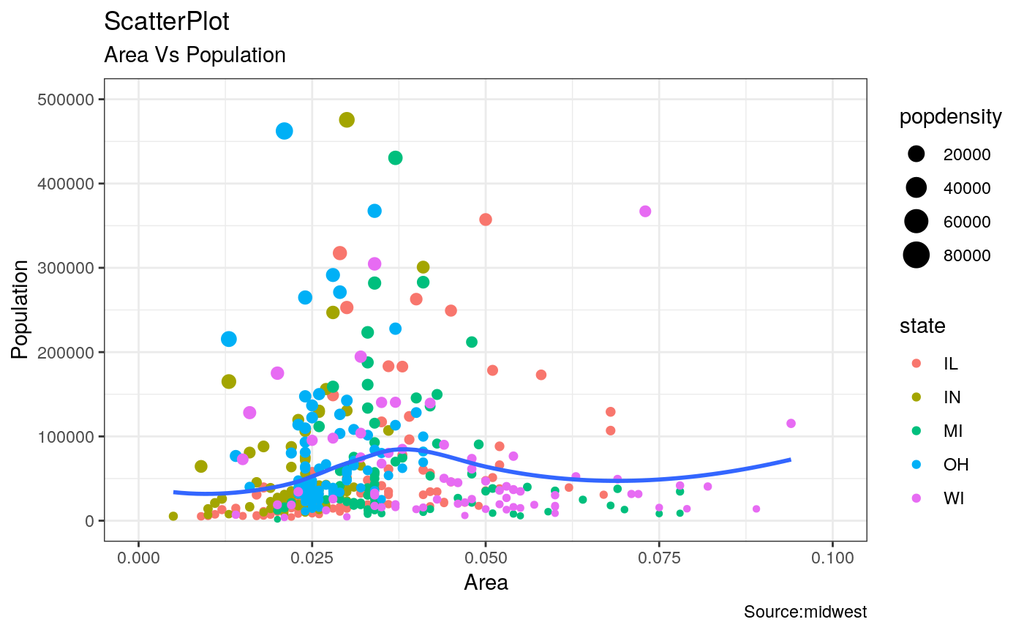

```r
gg <- ggplot(midwest, aes(x=area, y=poptotal)) +
  geom_point(aes(col=state, size=popdensity)) +
  geom_smooth(method = 'loess', se=F) +
  xlim(c(0,0.1)) +
  ylim(c(0,500000)) +
  labs(subtitle = "Area Vs Population",
       y="Population",
       x="Area",
       title = "ScatterPlot",
       caption = "Source:midwest")

plot(gg)
```

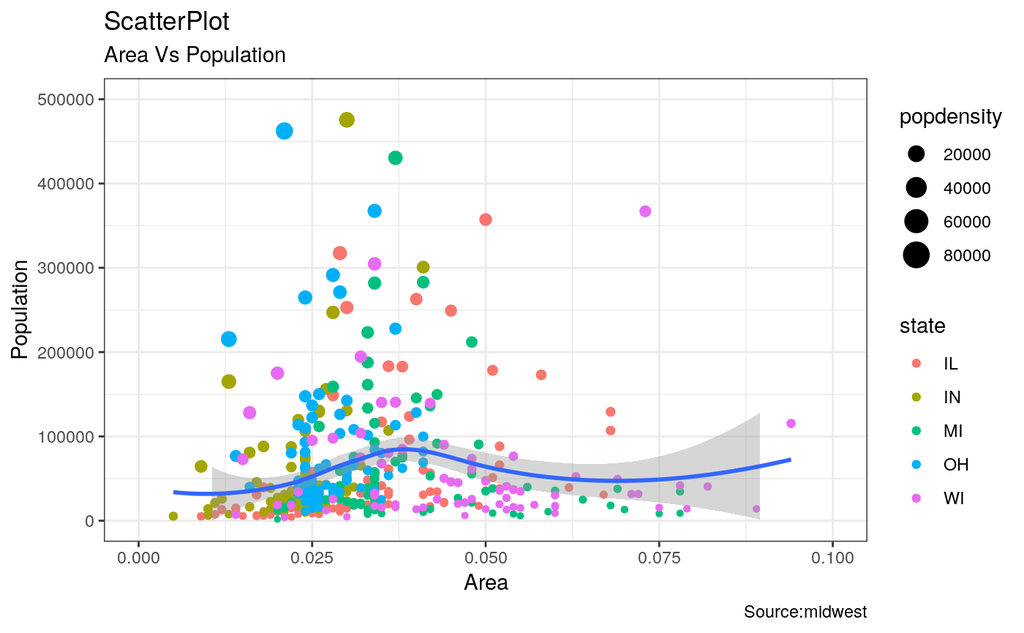

```r
gg <- ggplot(midwest, aes(x=area, y=poptotal)) +
  geom_point(aes(col=state, size=popdensity)) +
  geom_smooth(method = 'loess', se=T) +
  xlim(c(0,0.1)) +
  ylim(c(0,500000)) +
  labs(subtitle = "Area Vs Population",
       y="Population",
       x="Area",
       title = "ScatterPlot",
       caption = "Source:midwest")

plot(gg)
```

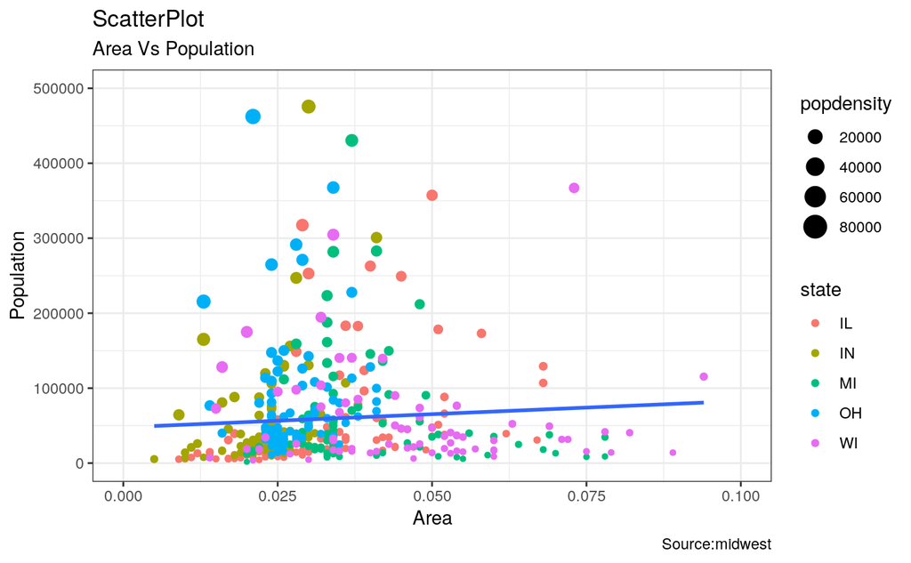

```r
gg <- ggplot(midwest, aes(x=area, y=poptotal)) +
  geom_point(aes(col=state, size=popdensity)) +
  geom_smooth(method = 'lm', se=F) +
  xlim(c(0,0.1)) +
  ylim(c(0,500000)) +
  labs(subtitle = "Area Vs Population",
       y="Population",
       x="Area",
       title = "ScatterPlot",
       caption = "Source:midwest")

plot(gg)
```

## 1.2绘制有内置圆圈的散点图Scatterplot With Encircling

在展示结果时，有时我会在图表中圈出某些特殊的点组或区域，以引起人们对这些特殊情况的注意。 这可以方便地使用 ggalt 包中的 geom_encircle() 来完成。

在 geom_encircle() 中，将数据设置为仅包含点（行）或感兴趣的新数据框。 此外，您可以扩展曲线，使其刚好超出点的范围。曲线的颜色和大小（厚度）也可以修改。

```r
options(scipen = 999)
library(ggplot2)
library(ggalt)
midwest_select <- midwest[midwest$poptotal > 350000 &
                            midwest$poptotal <= 500000 &
                            midwest$area > 0.01 &
                            midwest$area < 0.1,]
```

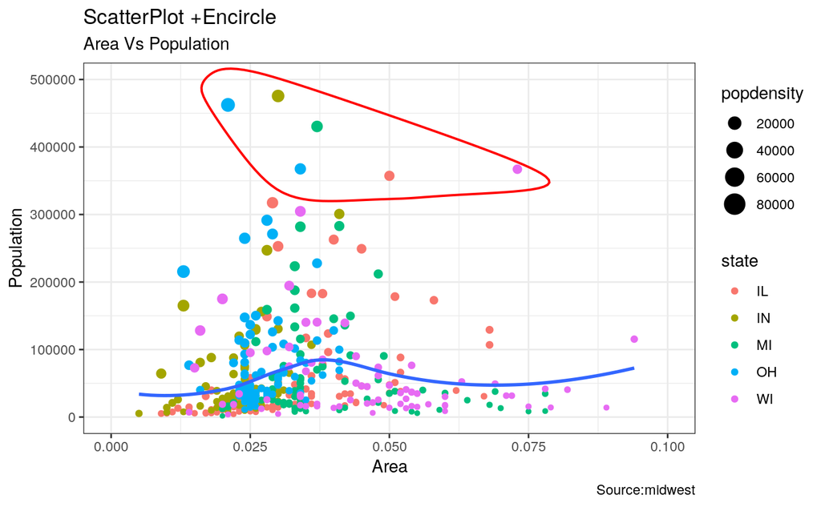

```r
gg <- ggplot(midwest, aes(x=area, y=poptotal)) +
        geom_point(aes(col=state, size=popdensity)) +
        geom_smooth(method = 'loess', se=F) +
        xlim(c(0,0.1)) +
        ylim(c(0,500000)) +
        geom_encircle(data=midwest_select, aes(x=area, y=poptotal), color='red', size=2, expand=0.08) +
        labs(subtitle = "Area Vs Population",
             y="Population",
             x="Area",
             title = "ScatterPlot +Encircle",
             caption = "Source:midwest")
plot(gg)
```

## 1.3 抖动散点图Jitter plot

适用于存在许多重叠的散点图

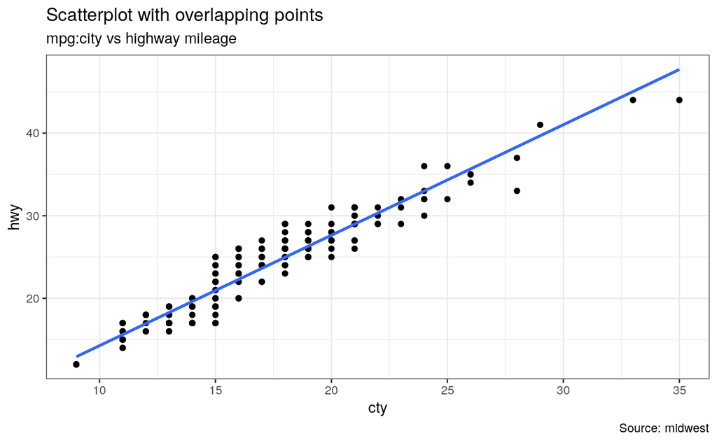

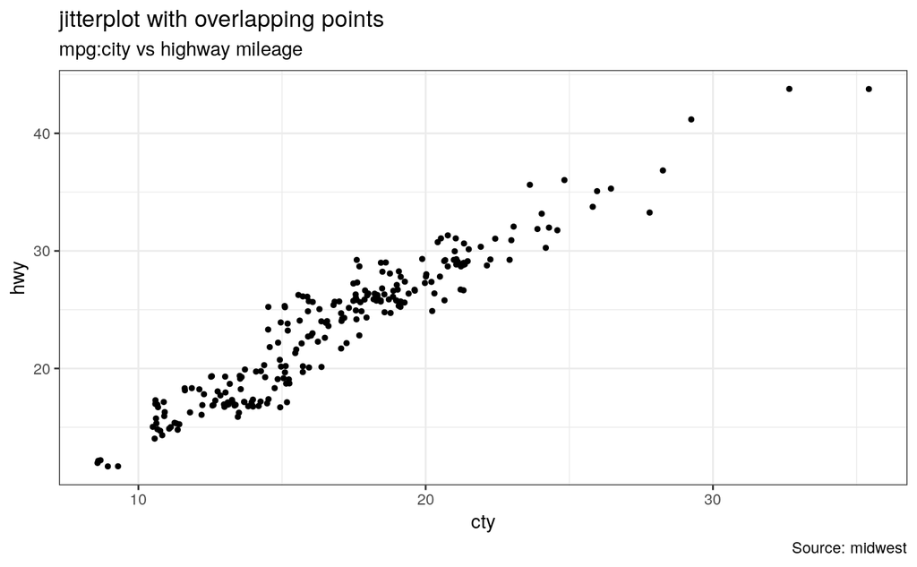

# 计数图Counts Chart

另外一种克服数据点重叠

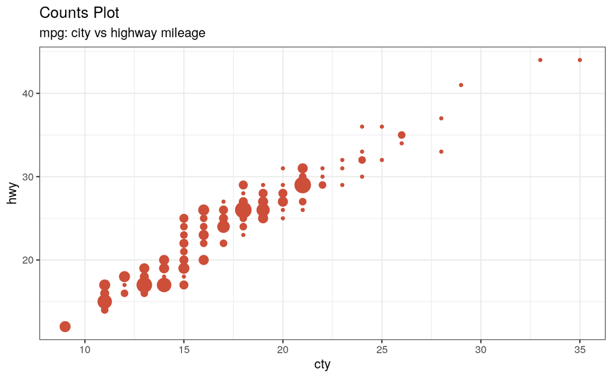

# 1.3 气泡图 bubble plot

当需要展示的数据信息多于2维时，可以考虑使用bubble plot

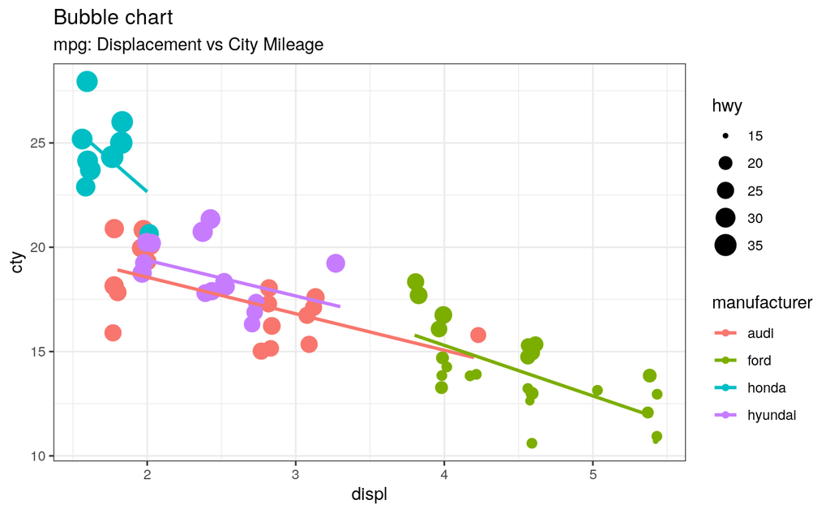

# 1.4 动态气泡图

`devtools::install_github("dgrtwo/gganimate")` `install.packages('gapmibder')`

```r
animate(g)
```

[output not shown]

# 1.5 Margin Histgram / Boxplot

为散点图附加直方图和箱线图，这里使用了ggExtra函数

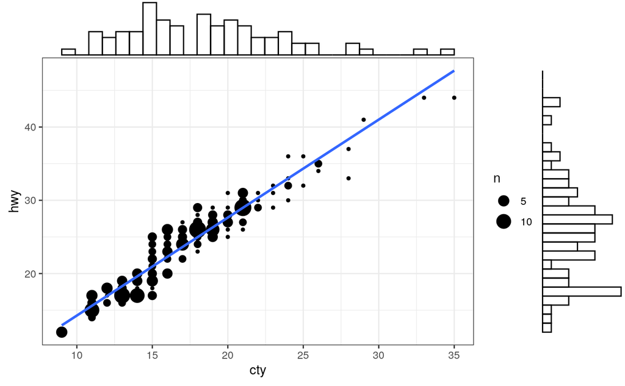

```r
ggMarginal(g, type = 'histogram', fill='transparent')
```

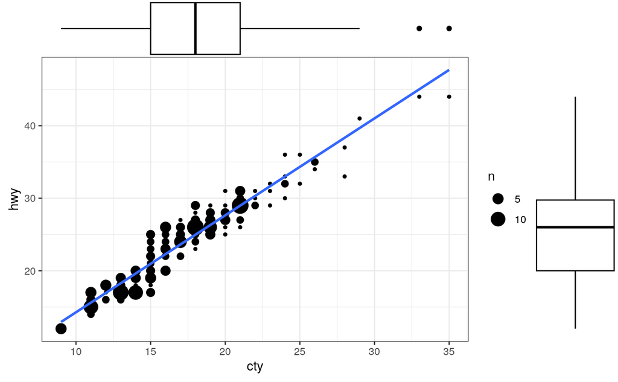

```r
ggMarginal(g, type = 'boxplot', fill='transparent')
```

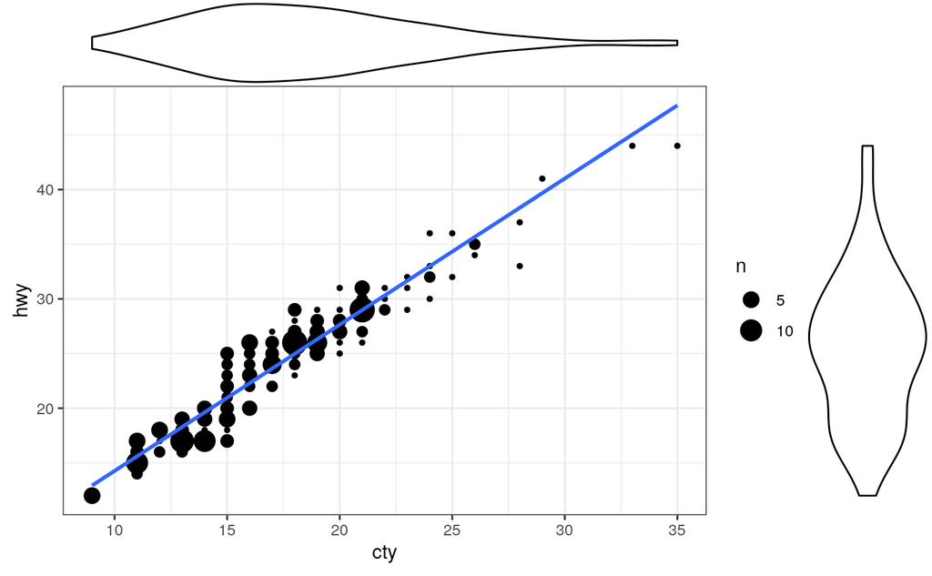

```r
ggMarginal(g, type = 'violin', fill='transparent')
```

# 1.6 相关性图correlogram

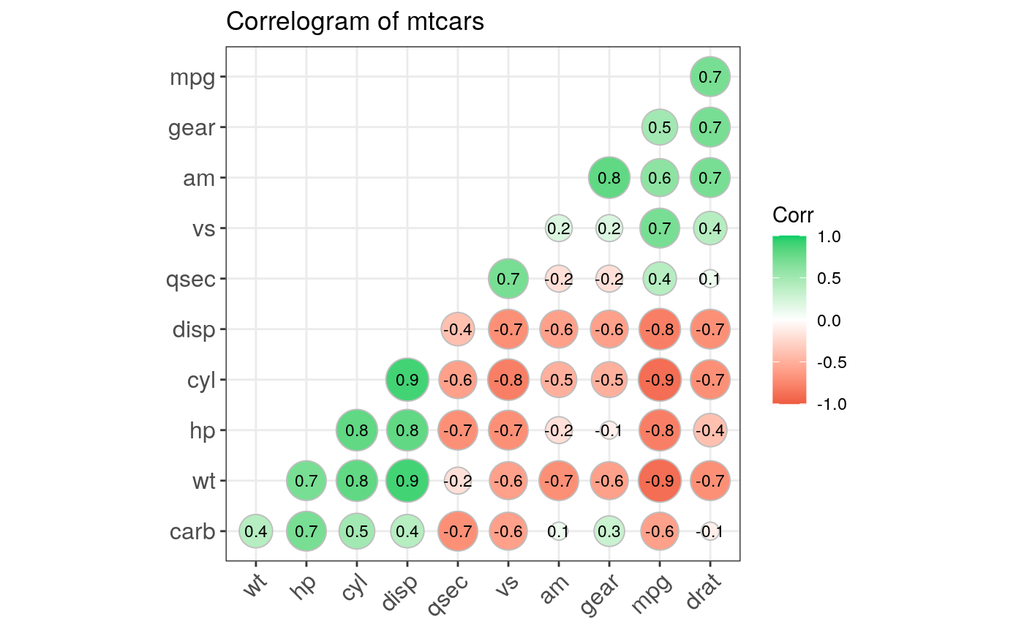

```r
# devtools::install_github("kassambara/ggcorrplot")
library(ggplot2)
library(ggcorrplot)

data(mtcars)
corr <- round(cor(mtcars), 1) # round函数用于四舍五入数据到小数点后几位，如这里是小数点后1位

ggcorrplot(corr, hc.order = TRUE, # 是否对相似性矩阵进行层次聚类
           type = 'lower', # full，lower，upper，分别表示使用全矩阵，下三角和上三角
           lab = TRUE, # 是否在图上的点加上相关性系数-标签
           lab_size = 3, # 大小
           method = 'circle', # 可选 square和circle，矩形还是圆形
           colors = c('tomato2', 'white', 'springgreen3'), # 颜色映射
           title = 'Correlogram of mtcars',
           ggtheme = theme_bw) # 使用ggplot2的主题设置
```

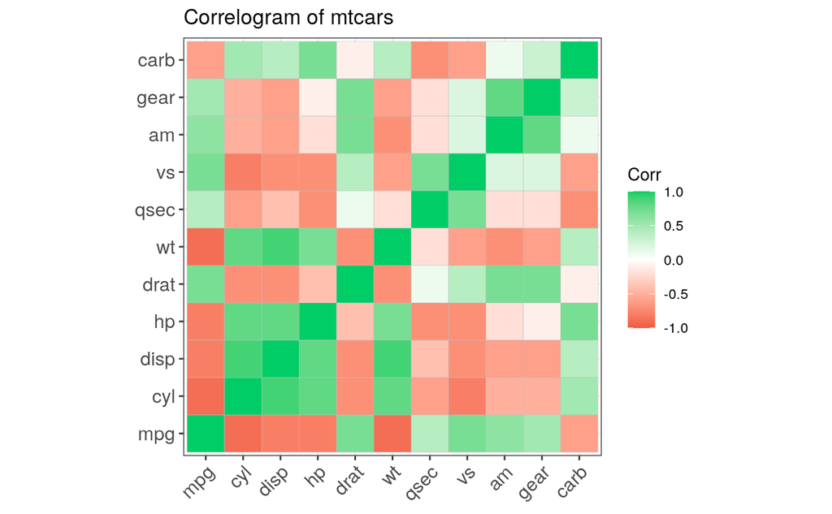